# IODS course project autumn 2023

# Assignment 3: Logistic regression

#### Name: Henna Kallo

#### Date: 18.11.2023

We are exploring data from two questionnaires related to student performance in secondary education of two Portuguese schools. The data includes student grades, demographic, social and school related variables. Here we have combined data sets of Mathematics and Portuguese language subjects.

Here we study the relationships between alcohol consumption with selected variables.

Data source: http://www.archive.ics.uci.edu/dataset/320/student+performance

```r
#import data
library(readr)
alc<-read_csv("C:/Users/Henna/Desktop/IODS/IODS-project/Data/student_performance_alcohol.csv")
alc<-as.data.frame(alc);

colnames(alc) #column names
```

```
##  [1] "school"     "sex"        "age"        "address"    "famsize"
##  [6] "Pstatus"    "Medu"       "Fedu"       "Mjob"       "Fjob"
## [11] "reason"     "guardian"   "traveltime" "studytime"  "schoolsup"
## [16] "famsup"     "activities" "nursery"    "higher"     "internet"
## [21] "romantic"   "famrel"     "freetime"   "goout"      "Dalc"
## [26] "Walc"       "health"     "failures"   "paid"       "absences"
## [31] "G1"         "G2"         "G3"         "alc_use"    "high_use"
```

```r
str(alc) #structure of the dataset
```

```
## 'data.frame':    370 obs. of  35 variables:
##  $ school    : chr  "GP" "GP" "GP" "GP" ...
##  $ sex       : chr  "F" "F" "F" "F" ...
##  $ age       : num  18 17 15 15 16 16 16 17 15 15 ...
##  $ address   : chr  "U" "U" "U" "U" ...
##  $ famsize   : chr  "GT3" "GT3" "LE3" "GT3" ...
##  $ Pstatus   : chr  "A" "T" "T" "T" ...
##  $ Medu      : num  4 1 1 4 3 4 2 4 3 3 ...
##  $ Fedu      : num  4 1 1 2 3 3 2 4 2 4 ...
##  $ Mjob      : chr  "at_home" "at_home" "at_home" "health" ...
##  $ Fjob      : chr  "teacher" "other" "other" "services" ...
##  $ reason    : chr  "course" "course" "other" "home" ...
##  $ guardian  : chr  "mother" "father" "mother" "mother" ...
##  $ traveltime: num  2 1 1 1 1 1 1 2 1 1 ...
##  $ studytime : num  2 2 2 3 2 2 2 2 2 2 ...
```

[output cut: 21 more lines]

All the variables listed. The variables not used for joining the two data have been combined by averaging (including the grade variables). Alcohol use (‘alc_use’) is the average of workday and weekend alcohol consumption. If average is higher than 2, alcohol consumption is considered ‘high use’. Rest of the variables are describes in the website (link given above).

We have 370 obsrevations and 35 variables in the dataframe. There are character, numerical and logistic type of variables.

Next we select 4 intersting variables to further study their relationship with the alcohol consumption. Let’s visualize the variables:

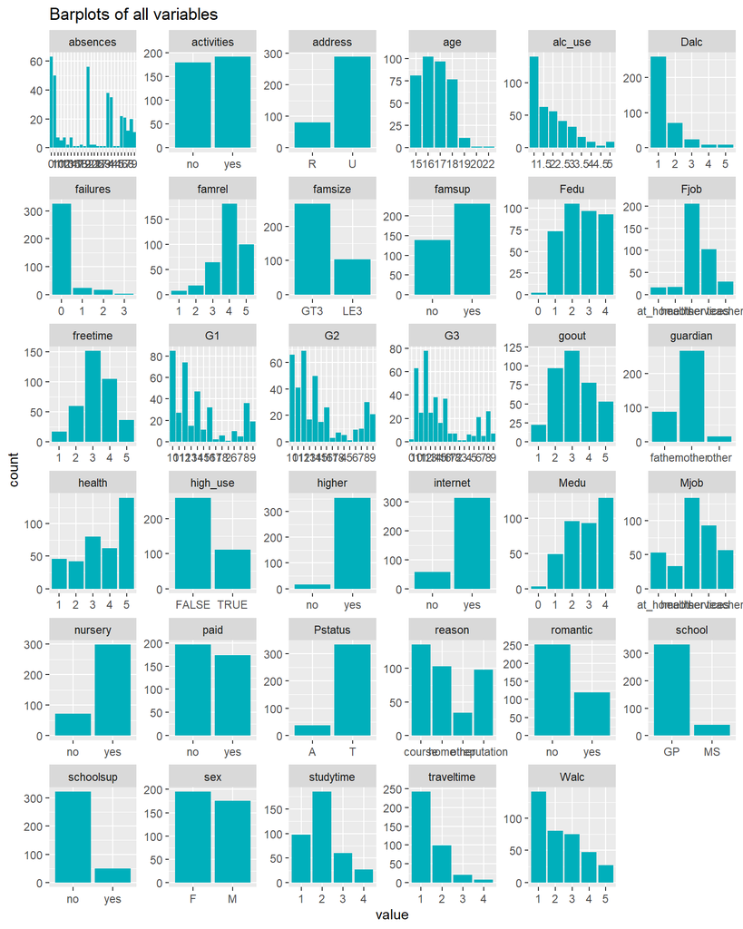

```r
library(tidyr); library(ggplot2); library(dplyr);
gather(alc) %>% ggplot(aes(value))  +
  facet_wrap("key", scales = "free") +
  geom_bar(fill="#00AFBB") +
  ggtitle("Barplots of all variables")
```

Below are listed the chosen 4 factors, brief description of variable, and expected relationship with alcohol consumption

- Goout
  - going out with friends, scoring 1-5
  - hypothesis: there is a positive relationship between ‘goout’ and ‘high_use’: higher value of the goout is linked with heavier alcohol consumption.
- Absences
  - number of school absences
  - hypothesis: there is a positive relationship between ‘absences’ and ‘high_use’: higher value of absences is linked with heavier alcohol consumption.
- Failures
  - number of past class failures
  - hypothesis: there is a positive relationship between ‘failures’ and ‘high_use’: higher value of failures is linked with heavier alcohol consumption.
- Romantic
  - with a romantic relationship (binary: yes or no)
  - hypothesis: there might be an association between variables ‘romantic’ and ‘high_use’: single status linked with high_use=TRUE.

Next we will see whether we can find support for our hypotheses with numerical and graphical exploration of data:

Density or frequency plots (depending on the variable), as well as cross-tabulations and plots to visualize

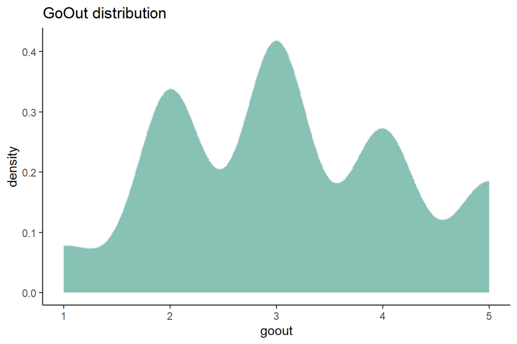

```r
ggplot(alc, aes(x=goout)) +
  geom_density(fill="#69b3a2", color="#e9ecef", alpha=0.8) +
  ggtitle("GoOut distribution") +
  theme_classic()
```

```r
# create cross-tabulations and plots to visualize
library(sjPlot)

tab_xtab(var.row = alc$goout, var.col = alc$high_use, title = "Cross-Tab of GoOut & High alcohol consumption", show.row.prc = TRUE)
```

Cross-Tab of GoOut & High alcohol consumption

| goout | high_use |  | Total |  |
| --- | --- | --- | --- | --- |
|  | FALSE | TRUE |  |  |
| 1 | 19 86.4 % | 3 13.6 % |  | 22 100 % |
| 2 | 82 84.5 % | 15 15.5 % | 97 100 % |  |
| 3 | 97 80.8 % | 23 19.2 % | 120 100 % |  |
| 4 | 40 51.3 % | 38 48.7 % | 78 100 % |  |
| 5 | 21 39.6 % | 32 60.4 % | 53 100 % |  |
| Total | 259 70 % | 111 30 % | 370 100 % |  |

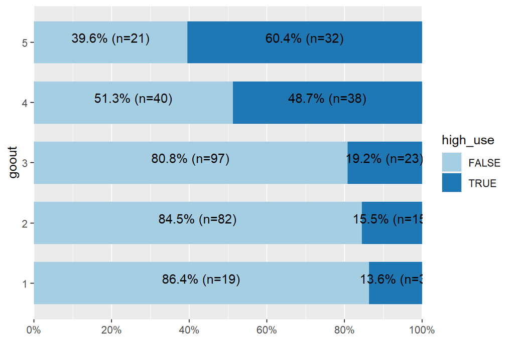

```r
plot_xtab(alc$goout, alc$high_use, margin = "row", bar.pos = "stack", coord.flip = TRUE)
```

Density plot shown that most of the students get ‘goout’ scoring 2-4. Cross-tabulation shows that the bigger is the ‘goout’ score, the bigger proportion there is of observations with high_use=TRUE. This indicates that our hypothesis was correct: higher value of the goout is linked with heavier alcohol consumption.

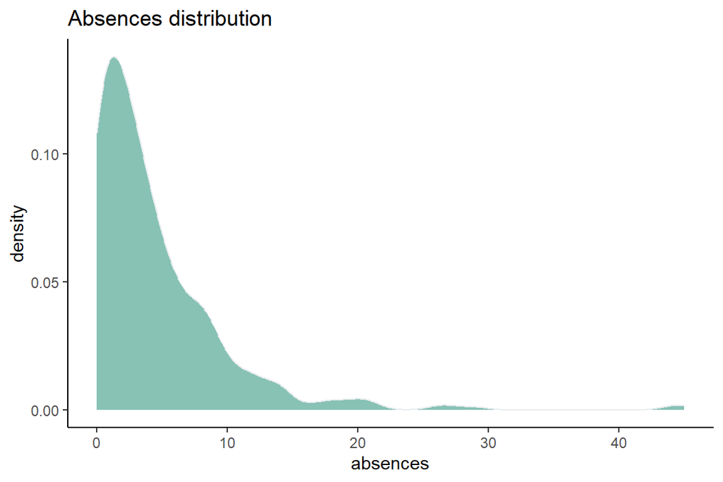

```r
ggplot(alc, aes(x=absences)) +
  geom_density(fill="#69b3a2", color="#e9ecef", alpha=0.8) +
  ggtitle("Absences distribution") +
  theme_classic()
```

```r
tab_xtab(var.row = alc$absences, var.col = alc$high_use, title = "Cross-Tab of Absences & High alcohol consumption", show.row.prc = TRUE)
```

Cross-Tab of Absences & High alcohol consumption

| absences | high_use |  | Total |  |
| --- | --- | --- | --- | --- |
|  | FALSE | TRUE |  |  |
| 0 | 50 79.4 % | 13 20.6 % |  | 63 100 % |
| 1 | 37 74 % | 13 26 % | 50 100 % |  |
| 2 | 40 71.4 % | 16 28.6 % | 56 100 % |  |
| 3 | 31 81.6 % | 7 18.4 % | 38 100 % |  |
| 4 | 24 68.6 % | 11 31.4 % | 35 100 % |  |
| 5 | 16 72.7 % | 6 27.3 % | 22 100 % |  |
| 6 | 16 76.2 % | 5 23.8 % | 21 100 % |  |
| 7 | 9 75 % | 3 25 % | 12 100 % |  |
| 8 | 14 70 % | 6 30 % | 20 100 % |  |
| 9 | 5 45.5 % | 6 54.5 % | 11 100 % |  |
| 10 | 5 71.4 % | 2 28.6 % | 7 100 % |  |
| 11 | 2 40 % | 3 60 % | 5 100 % |  |
| 12 | 3 42.9 % | 4 57.1 % | 7 100 % |  |
| 13 | 1 50 % | 1 50 % | 2 100 % |  |
| 14 | 1 14.3 % | 6 85.7 % | 7 100 % |  |
| 16 | 0 0 % | 1 100 % | 1 100 % |  |
| 17 | 0 0 % | 1 100 % | 1 100 % |  |
| 18 | 1 50 % | 1 50 % | 2 100 % |  |
| 19 | 0 0 % | 1 100 % | 1 100 % |  |
| 20 | 2 100 % | 0 0 % | 2 100 % |  |
| 21 | 1 50 % | 1 50 % | 2 100 % |  |
| 26 | 0 0 % | 1 100 % | 1 100 % |  |
| 27 | 0 0 % | 1 100 % | 1 100 % |  |
| 29 | 0 0 % | 1 100 % | 1 100 % |  |
| 44 | 0 0 % | 1 100 % | 1 100 % |  |
| 45 | 1 100 % | 0 0 % | 1 100 % |  |
| Total | 259 70 % | 111 30 % | 370 100 % |  |

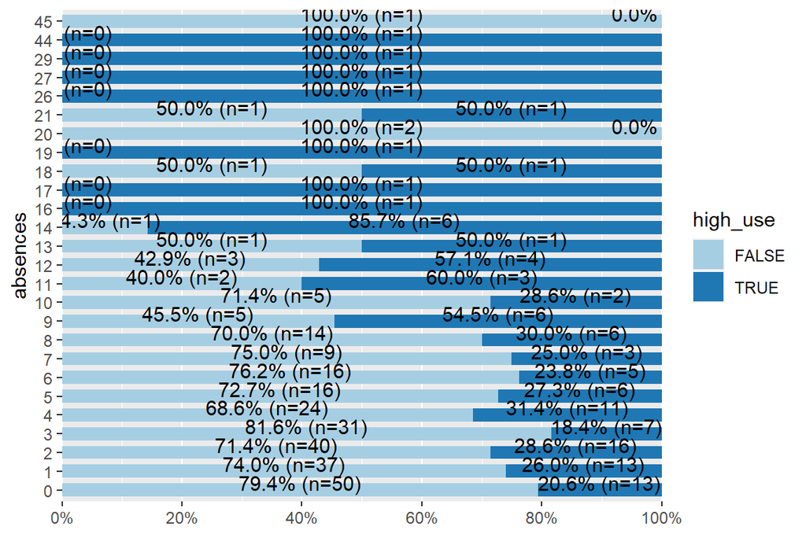

```r
plot_xtab(alc$absences, alc$high_use, margin = "row", bar.pos = "stack", coord.flip = TRUE)
```

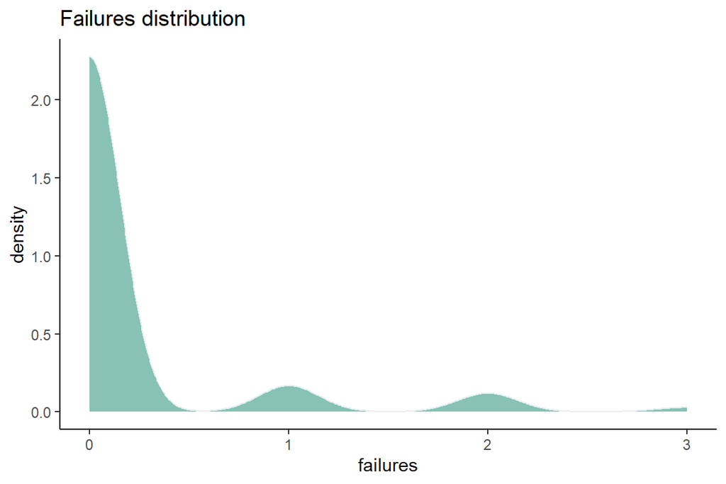

```r
ggplot(alc, aes(x=failures)) +
  geom_density(fill="#69b3a2", color="#e9ecef", alpha=0.8) +
  ggtitle("Failures distribution") +
  theme_classic()
```

```r
tab_xtab(var.row = alc$failures, var.col = alc$high_use, title = "Cross-Tab of failures & High alcohol consumption", show.row.prc = TRUE)
```

Cross-Tab of failures & High alcohol consumption

| failures | high_use |  | Total |  |
| --- | --- | --- | --- | --- |
|  | FALSE | TRUE |  |  |
| 0 | 238 73.2 % | 87 26.8 % |  | 325 100 % |
| 1 | 12 50 % | 12 50 % | 24 100 % |  |
| 2 | 8 47.1 % | 9 52.9 % | 17 100 % |  |
| 3 | 1 25 % | 3 75 % | 4 100 % |  |
| Total | 259 70 % | 111 30 % | 370 100 % |  |

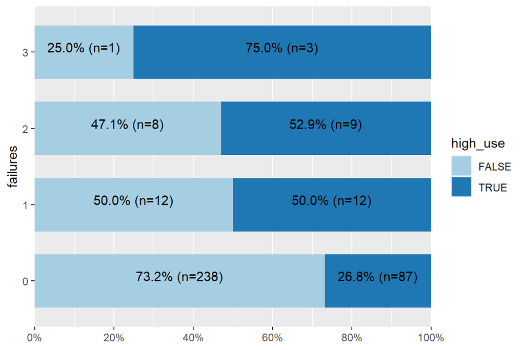

```r
plot_xtab(alc$failures, alc$high_use, margin = "row", bar.pos = "stack", coord.flip = TRUE)
```

Also the density plot of failures is right skewed, meaning that most of the student pass the class Cross-tabulation shows that higher number of failures is linked with the bigger proportion of high alcohol consumption. This indicates that our hypothesis was correct: higher value of failures is linked with increase in heavy alcohol consumption.

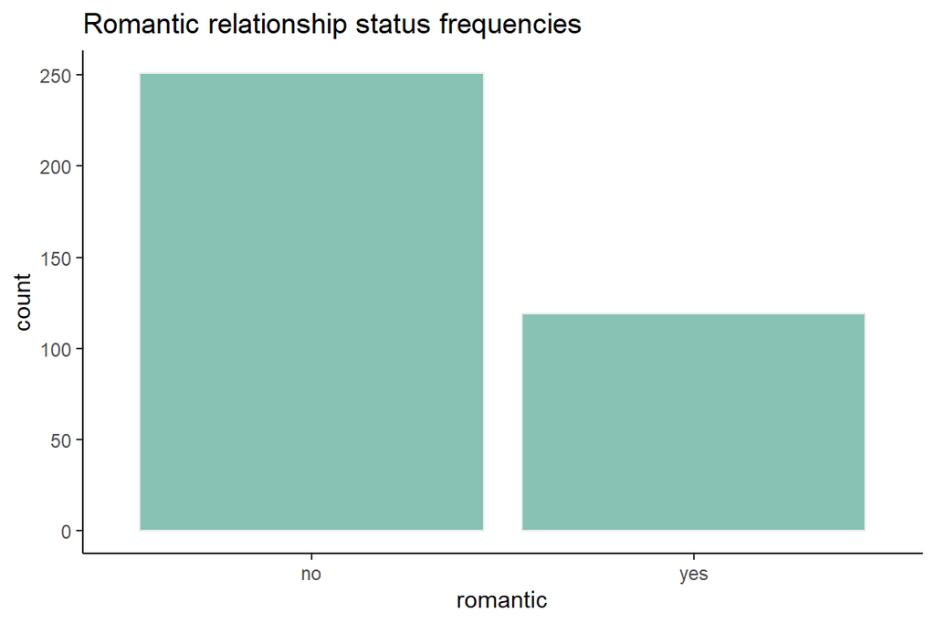

```r
ggplot(alc, aes(x=romantic)) +
  geom_bar(fill="#69b3a2", color="#e9ecef", alpha=0.8) +
  ggtitle("Romantic relationship status frequencies") +
  theme_classic()
```

```r
tab_xtab(var.row = alc$romantic, var.col = alc$high_use, title = "Cross-Tab of Romantic relationship status & High alcohol consumption", show.row.prc = TRUE)
```

Cross-Tab of Romantic relationship status & High alcohol consumption

| romantic | high_use |  | Total |  |
| --- | --- | --- | --- | --- |
|  | FALSE | TRUE |  |  |
| no | 173 68.9 % | 78 31.1 % |  | 251 100 % |
| yes | 86 72.3 % | 33 27.7 % | 119 100 % |  |
| Total | 259 70 % | 111 30 % | 370 100 % |  |

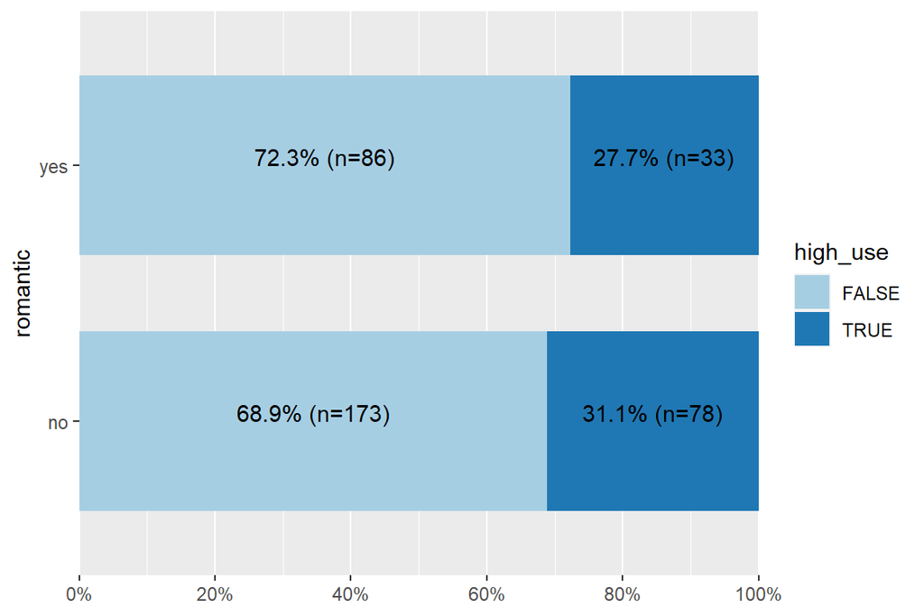

```r
plot_xtab(alc$romantic, alc$high_use, margin = "row", bar.pos = "stack", coord.flip = TRUE)
```

The frequency table shows that there is about 1/3 of students in romantic relationship whereas ~2/3 are with single status. Cross-tabulation indicates that even though there is slightly bigger percentage of single + high alc use students, this difference is most likely not statistically meaningful. Thus, this results does not support our hypothesis stating ‘there might be an association between variables ’romantic’ and ‘high_use’’.

We are interested whether the alcohol consumption has an association with the chosen set of characteristics of the students. Binary logistic regression can tell us the probability of this. We choose binary logistic regression because the outcome variable, ‘high_use’, has two level (TRUE/FALSE). Explanatory variables can be other types as well.

```r
#binary logistic regression
m <- glm(high_use ~ failures + absences + goout + romantic, data = alc, family = "binomial")

summary(m) # a summary of the model
```

```
##
## Call:
## glm(formula = high_use ~ failures + absences + goout + romantic,
##     family = "binomial", data = alc)
##
## Deviance Residuals:
##     Min       1Q   Median       3Q      Max
## -2.0472  -0.7510  -0.5266   0.8886   2.3474
##
## Coefficients:
##             Estimate Std. Error z value Pr(>|z|)
## (Intercept) -3.55115    0.44211  -8.032 9.57e-16 ***
## failures     0.56492    0.22385   2.524 0.011612 *
## absences     0.07762    0.02243   3.461 0.000538 ***
## goout        0.70634    0.11846   5.963 2.48e-09 ***
## romanticyes -0.35224    0.27737  -1.270 0.204111
## ---
## Signif. codes:  0 '***' 0.001 '**' 0.01 '*' 0.05 '.' 0.1 ' ' 1
##
## (Dispersion parameter for binomial family taken to be 1)
##
##     Null deviance: 452.04  on 369  degrees of freedom
## Residual deviance: 382.41  on 365  degrees of freedom
## AIC: 392.41
##
## Number of Fisher Scoring iterations: 4
```

Let’s go through the output:

First we have the distribution of the deviance residuals.

The next we get the coefficients, their standard errors, the z-statistic, and the associated p-values. Failures, absences and goout are statistically significant. Variable ‘romantic’ is non-significant.

The logistic regression coefficients give the change in the log odds of the outcome (high_use) for a one unit increase in the predictor variable: + for every one unit change in failures, the log odds of high_use=yes increases by 0.56. + for every one unit change in absences, the log odds of high_use=yes increases by 0.08. + for every one unit change in goout, the log odds of high_use=yes increases by 0.71.

From the results we can construct the logistic regression equation (leave out statistically non-significant variable):

log(odds[high_use=yes]) = -3.55115 + 0.56492 * failures + 0.07762 * absences + 0.70634 * goout

Next we will compute the odds ratios (OR) and confidence intervalss (CI):

```r
coef(m) # the coefficients of the model
```

```
## (Intercept)    failures    absences       goout romanticyes
## -3.55114961  0.56492346  0.07762078  0.70634191 -0.35223716
```

```r
OR <- coef(m) %>% exp # compute odds ratios (OR)

CI <-  confint(m) %>% exp # compute confidence intervals (CI)

cbind(OR, CI) # print out the odds ratios with their confidence intervals
```

```
##                     OR      2.5 %     97.5 %
## (Intercept) 0.02869164 0.01165358 0.06618211
## failures    1.75931312 1.14014676 2.75402869
## absences    1.08071276 1.03551949 1.13208308
## goout       2.02656433 1.61539789 2.57288191
## romanticyes 0.70311335 0.40369796 1.20112415
```

We can conclude the following: - for one unit increase in failures, the odds of having high alcohol consumption increases by factor of 1.76. (the outcome is 76% more likely) - for one unit increase in absences, the odds of having high alcohol consumption increases by factor of 1.08. (the outcome is 8% more likely) - for one unit increase in goout, the odds of having high alcohol consumption increases by factor of 2.03. (there is a doubling of the odds of the outcome)

CI is used to estimate the precision of the OR. A large CI indicates a low level of precision of the OR, whereas a small CI indicates a higher precision of the OR.

These results support our hypotheses of the effects of failures, absences and goouts, but not about the effect of romantic relationship status.

Next, we will explore the predictive power of the model. We will include only the statistically significant variables: failures, absences & goout.

```r
m_pred <- glm(high_use ~ failures + absences + goout, data = alc, family = "binomial")

probabilities <- predict(m_pred, type = "response") # predict the probability of high_use

alc <- mutate(alc, probability = probabilities) # add the predicted probabilities to 'alc'

alc <- mutate(alc, prediction = probability > 0.5) # use the probabilities to make a prediction of high_use

# see the last ten original classes, predicted probabilities, and class predictions
select(alc, failures, absences, goout, high_use, probability, prediction) %>% tail(10)
```

```
##     failures absences goout high_use probability prediction
## 361        0        3     3    FALSE  0.21435314      FALSE
## 362        1        0     2    FALSE  0.15791281      FALSE
## 363        1        7     3     TRUE  0.38937775      FALSE
## 364        0        1     3    FALSE  0.19036196      FALSE
## 365        0        6     3    FALSE  0.25431749      FALSE
## 366        1        2     2    FALSE  0.17871716      FALSE
## 367        0        2     4    FALSE  0.33847888      FALSE
## 368        0        3     1    FALSE  0.06266341      FALSE
## 369        0        4     5     TRUE  0.54534711       TRUE
## 370        0        2     1     TRUE  0.05843362      FALSE
```

```r
table(high_use = alc$high_use, prediction = alc$prediction) # tabulate the target variable versus the predictions
```

```
##         prediction
## high_use FALSE TRUE
##    FALSE   237   22
##    TRUE     66   45
```

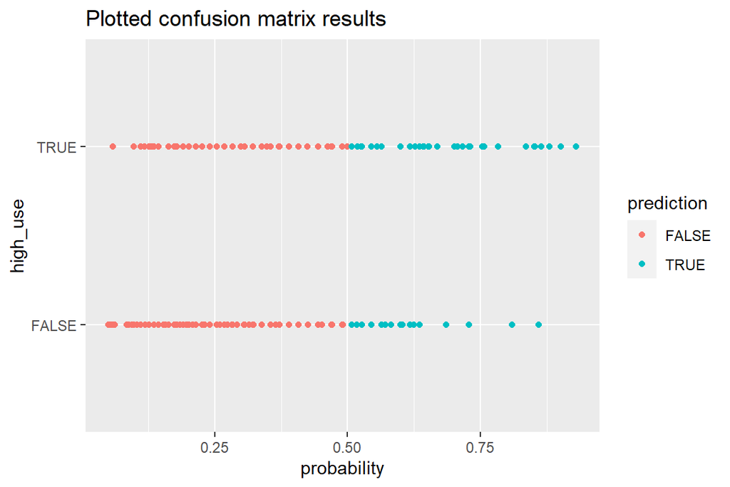

```r
ggplot(alc, aes(x = probability, y = high_use, col = prediction))+ #plot of 'high_use' versus 'probability' in 'alc'
  geom_point()+
  ggtitle("Plotted confusion matrix results ")
```

The printout of the dataframe shows the new columns; predicted probabilities and prediction of high_use.

A confusion matrix visualizes and summarizes the performance of a classification algorithm: + true negatives: 237 + true positives: 45 + false positives (type I error): 22 + false negatives (type II error): 66

Next, let’s compute the average number of incorrect predictions. The mean of incorrectly classified observations can be thought of as a penalty (loss) function for the classifier. Less penalty = good.

```r
table(high_use = alc$high_use, prediction = alc$prediction) %>% # tabulate the target variable versus the predictions
  prop.table() %>%
  addmargins()
```

```
##         prediction
## high_use      FALSE       TRUE        Sum
##    FALSE 0.64054054 0.05945946 0.70000000
##    TRUE  0.17837838 0.12162162 0.30000000
##    Sum   0.81891892 0.18108108 1.00000000
```

```r
loss_func <- function(class, prob) { # define a loss function (mean prediction error)
  n_wrong <- abs(class - prob) > 0.5
  mean(n_wrong)
}

loss_func(class = alc$high_use, prob = alc$probability) #compute the average number of wrong predictions in the (training) data
```

```
## [1] 0.2378378
```

This analysis revealed that the average number of wrong predictions is ~24%.

Now we continue to the 10-fold cross-validation of the model

```r
# K-fold cross-validation
library(boot)
#trainingdata
cv_train <- cv.glm(data = alc, cost = loss_func, glmfit = m_pred, K = nrow(alc))

#testingdata
cv_test <- cv.glm(data = alc, cost = loss_func, glmfit = m_pred, K = 10)

# average number of wrong predictions
cv_train$delta[1]
```

```
## [1] 0.2405405
```

```r
cv_test$delta[1]
```

```
## [1] 0.2405405
```

# Assignment 4: Clustering & Classification

#### Name: Henna Kallo

#### Date: 26.11.2023

#### In this exercise we learn data clustering and classification

- Data source: MASS package in R: https://stat.ethz.ch/R-manual/R-devel/library/MASS/html/Boston.html
- Literature: Part IV of “MABS4IODS” (chapters 12, 17 & 18)
- Important concepts:
  - Classification: organizing a large, complex set of multivariate data. Objects are sorted into a small number of homogeneous groups or clusters.
  - Multivariate data: several measurements or observations are made on each sampling unit, and they are considered simultaneously to reveal the patterns or so. No division to explanatory and dependent variables.

```r
library(MASS); library(tidyr); library(corrplot); library(dplyr); library(ggplot2) #load libraries
rm(list=ls())
data("Boston") #load the data
```

Let’s take a look of the Boston data:

```r
str(Boston) #structure of the dataset
```

```
## 'data.frame':    506 obs. of  14 variables:
##  $ crim   : num  0.00632 0.02731 0.02729 0.03237 0.06905 ...
##  $ zn     : num  18 0 0 0 0 0 12.5 12.5 12.5 12.5 ...
##  $ indus  : num  2.31 7.07 7.07 2.18 2.18 2.18 7.87 7.87 7.87 7.87 ...
##  $ chas   : int  0 0 0 0 0 0 0 0 0 0 ...
##  $ nox    : num  0.538 0.469 0.469 0.458 0.458 0.458 0.524 0.524 0.524 0.524 ...
##  $ rm     : num  6.58 6.42 7.18 7 7.15 ...
##  $ age    : num  65.2 78.9 61.1 45.8 54.2 58.7 66.6 96.1 100 85.9 ...
##  $ dis    : num  4.09 4.97 4.97 6.06 6.06 ...
##  $ rad    : int  1 2 2 3 3 3 5 5 5 5 ...
##  $ tax    : num  296 242 242 222 222 222 311 311 311 311 ...
##  $ ptratio: num  15.3 17.8 17.8 18.7 18.7 18.7 15.2 15.2 15.2 15.2 ...
##  $ black  : num  397 397 393 395 397 ...
##  $ lstat  : num  4.98 9.14 4.03 2.94 5.33 ...
##  $ medv   : num  24 21.6 34.7 33.4 36.2 28.7 22.9 27.1 16.5 18.9 ...
```

- Boston dataset consists multivariate data of Housing values in suburdbs of Boston. The data frame has 506 rows and 14 variables. All variables are numeric type. Brief description of the variables:
  - crim: crime rates
  - zn: proportions of residental land zoned for lots over 25000 sq. ft.
  - indus: proportion of other than retail business acres
  - chas: next to Charles River, or not
  - nox: pollution; nitrogen oxides
  - rm: number of rooms per apartment
  - age: proportion of owner-occupied units built before 1940
  - dis: distances to the employment centres (weighted mean)
  - rad: access to radial highways
  - tax: full-value property-tax rate
  - ptratio: student/teacher ratio
  - black: 1000(Bk−0.63)^2 where Bk is the proportion of blacks by town.
  - lstat: lower status of the population (%)
  - medv: median value of owner-occupied homes in $1000s

With this data set we can explore connections between economical, environmental, societal and cultural features.

The descriptions of the variables are listed in here: https://stat.ethz.ch/R-manual/R-devel/library/MASS/html/Boston.html.

Let’s explore the summary statistics of the multivariate Boston data:

– each of the variables separately

– relationships between the variables (correlations)

```r
summary(Boston) #summary of each variable separately
```

```
##       crim                zn             indus            chas
##  Min.   : 0.00632   Min.   :  0.00   Min.   : 0.46   Min.   :0.00000
##  1st Qu.: 0.08205   1st Qu.:  0.00   1st Qu.: 5.19   1st Qu.:0.00000
##  Median : 0.25651   Median :  0.00   Median : 9.69   Median :0.00000
##  Mean   : 3.61352   Mean   : 11.36   Mean   :11.14   Mean   :0.06917
##  3rd Qu.: 3.67708   3rd Qu.: 12.50   3rd Qu.:18.10   3rd Qu.:0.00000
##  Max.   :88.97620   Max.   :100.00   Max.   :27.74   Max.   :1.00000
##       nox               rm             age              dis
##  Min.   :0.3850   Min.   :3.561   Min.   :  2.90   Min.   : 1.130
##  1st Qu.:0.4490   1st Qu.:5.886   1st Qu.: 45.02   1st Qu.: 2.100
##  Median :0.5380   Median :6.208   Median : 77.50   Median : 3.207
##  Mean   :0.5547   Mean   :6.285   Mean   : 68.57   Mean   : 3.795
##  3rd Qu.:0.6240   3rd Qu.:6.623   3rd Qu.: 94.08   3rd Qu.: 5.188
##  Max.   :0.8710   Max.   :8.780   Max.   :100.00   Max.   :12.127
##       rad              tax           ptratio          black
##  Min.   : 1.000   Min.   :187.0   Min.   :12.60   Min.   :  0.32
##  1st Qu.: 4.000   1st Qu.:279.0   1st Qu.:17.40   1st Qu.:375.38
##  Median : 5.000   Median :330.0   Median :19.05   Median :391.44
##  Mean   : 9.549   Mean   :408.2   Mean   :18.46   Mean   :356.67
##  3rd Qu.:24.000   3rd Qu.:666.0   3rd Qu.:20.20   3rd Qu.:396.23
##  Max.   :24.000   Max.   :711.0   Max.   :22.00   Max.   :396.90
##      lstat            medv
##  Min.   : 1.73   Min.   : 5.00
##  1st Qu.: 6.95   1st Qu.:17.02
##  Median :11.36   Median :21.20
##  Mean   :12.65   Mean   :22.53
##  3rd Qu.:16.95   3rd Qu.:25.00
##  Max.   :37.97   Max.   :50.00
```

The scatterplot of each variable-combination can be use as the first indicative visualization of associations between the variables. In addition to this, we print an illustrative correlation matrix visualization, which presents us nicely how strong is the association between the variable-pairs, and whether the association is positive or negative.

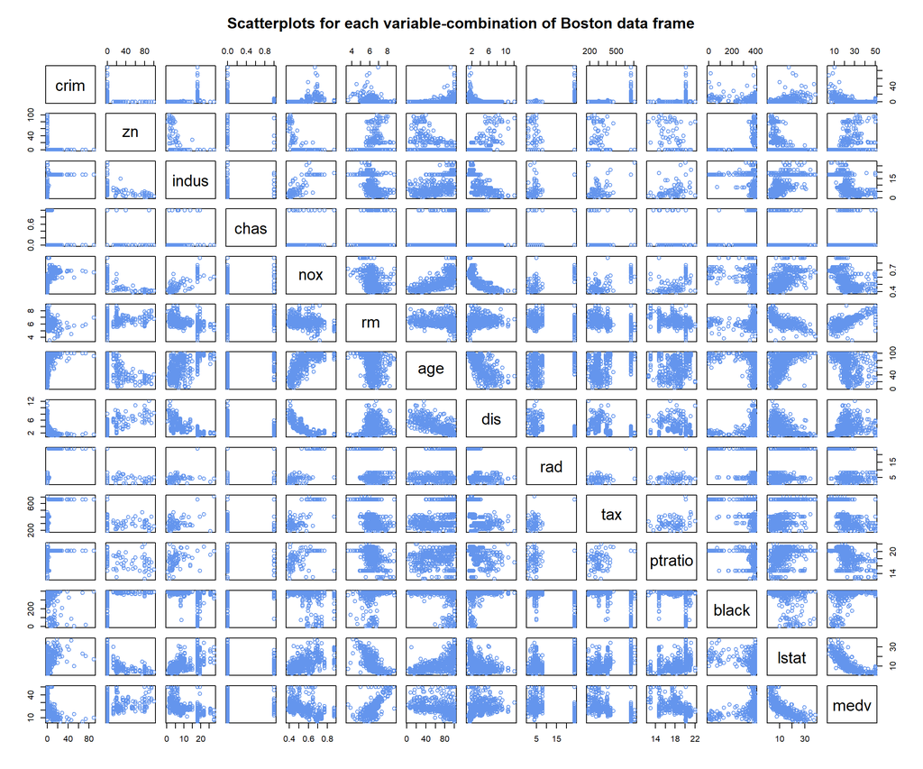

```r
pairs(Boston,
      col = "cornflowerblue",
      main = "Scatterplots for each variable-combination of Boston data frame")
```

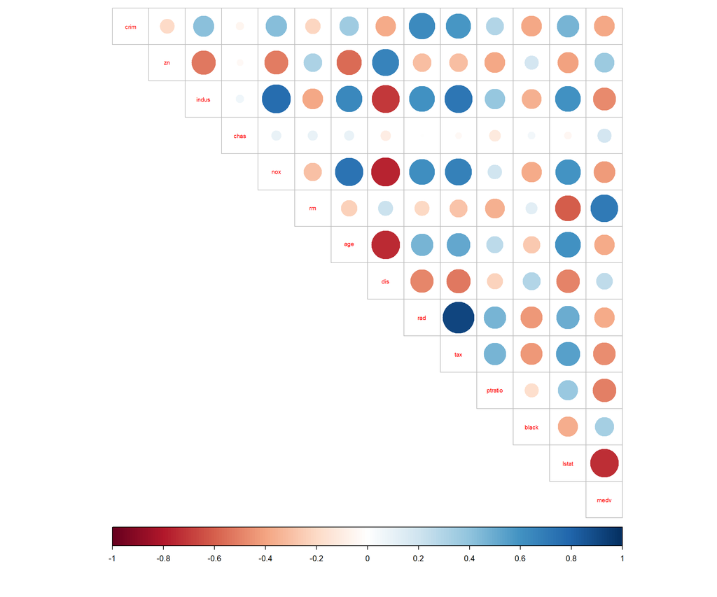

```r
cor_matrix <- cor(Boston) %>% #correlation matrix
  round(digits=2)

corrplot(cor_matrix, method="circle", type="upper", cl.pos = "b", tl.pos = "d", tl.cex = 0.6) ##visualize the correlations
```

The crime rate seems to be slightly positively associated with proportion of owner-occupied units built prior to 1940 and lower status of the population. Also, as accessibility to radial highways gets better and property-tax rate increases, the crime rates per capita increases.

Not that surprisingly, there is an association between industry and nitrogen oxygen levels. Moreover, higher nitrogen oxygen concentration seems to be associated with higher proportion of owner-occupied units built prior to 1940 & lower population status. The scatterplot indicates that the air pollution concentration and industry variables are in turn negatively associated with the distance to the Boston employment centres and median value of owner-occupied homes.

Lower number of rooms/apartment seems to be linked with lower population status. As expected, average number of rooms is positively associated with the median value of owner occupied homes. Lower status of the population is clearly linked with reduced median value of owner-occupied homes.

Moreover, there is a negative association between proportion of owner-occupied unit built prior to 1940 with distance to employment centres, and a positive correlation between the accessibility to radial highways and full-value property-tax rate per $10000.

The variables are on very different scales. We will make them more comparable by standardizing the dataset.

```r
boston_scaled <- scale(Boston) # center and standardize variables

summary(boston_scaled) # summaries of the scaled variables
```

```
##       crim                 zn               indus              chas
##  Min.   :-0.419367   Min.   :-0.48724   Min.   :-1.5563   Min.   :-0.2723
##  1st Qu.:-0.410563   1st Qu.:-0.48724   1st Qu.:-0.8668   1st Qu.:-0.2723
##  Median :-0.390280   Median :-0.48724   Median :-0.2109   Median :-0.2723
##  Mean   : 0.000000   Mean   : 0.00000   Mean   : 0.0000   Mean   : 0.0000
##  3rd Qu.: 0.007389   3rd Qu.: 0.04872   3rd Qu.: 1.0150   3rd Qu.:-0.2723
##  Max.   : 9.924110   Max.   : 3.80047   Max.   : 2.4202   Max.   : 3.6648
##       nox                rm               age               dis
##  Min.   :-1.4644   Min.   :-3.8764   Min.   :-2.3331   Min.   :-1.2658
##  1st Qu.:-0.9121   1st Qu.:-0.5681   1st Qu.:-0.8366   1st Qu.:-0.8049
##  Median :-0.1441   Median :-0.1084   Median : 0.3171   Median :-0.2790
##  Mean   : 0.0000   Mean   : 0.0000   Mean   : 0.0000   Mean   : 0.0000
##  3rd Qu.: 0.5981   3rd Qu.: 0.4823   3rd Qu.: 0.9059   3rd Qu.: 0.6617
##  Max.   : 2.7296   Max.   : 3.5515   Max.   : 1.1164   Max.   : 3.9566
##       rad               tax             ptratio            black
##  Min.   :-0.9819   Min.   :-1.3127   Min.   :-2.7047   Min.   :-3.9033
##  1st Qu.:-0.6373   1st Qu.:-0.7668   1st Qu.:-0.4876   1st Qu.: 0.2049
##  Median :-0.5225   Median :-0.4642   Median : 0.2746   Median : 0.3808
##  Mean   : 0.0000   Mean   : 0.0000   Mean   : 0.0000   Mean   : 0.0000
##  3rd Qu.: 1.6596   3rd Qu.: 1.5294   3rd Qu.: 0.8058   3rd Qu.: 0.4332
##  Max.   : 1.6596   Max.   : 1.7964   Max.   : 1.6372   Max.   : 0.4406
##      lstat              medv
##  Min.   :-1.5296   Min.   :-1.9063
##  1st Qu.:-0.7986   1st Qu.:-0.5989
##  Median :-0.1811   Median :-0.1449
##  Mean   : 0.0000   Mean   : 0.0000
##  3rd Qu.: 0.6024   3rd Qu.: 0.2683
##  Max.   : 3.5453   Max.   : 2.9865
```

When scaling the data, we subtract the column means from the corresponding columns and divide the difference with standard deviation. This is why the mean is 0 in all of the variables. After scaling (centering & standardizing) we can better compare the variables with each other. This website briefly lists the cons of centering and scaling the variables: https://www.goldsteinepi.com/blog/thewhyandwhenofcenteringcontinuouspredictorsinregressionmodeling/index.html

#### Classification

##### Linear discriminant analysis

“A further question that is often of interest for grouped multivariate data is whether or not it is possible to use the measurements made to construct a classification rule derived from the original observations (the training set) that will allow new individuals having the same set of measurements (the test sample).” -Part IV of “MABS4IODS” -> discriminant function analysis (chapter 18)

Now will perform linear discriminant analysis: the idea is to find a linear combination of features that characterizes or separates two or more classes of objects or events. When we want to use a statistical method to predict something, it is important to have data to test how well the predictions fit. Splitting the original data to test and train sets allows us to check how well our model works.

Our target variable is crime rate per capita by town. Rest of the variables are predictor variables. Our interest lies in deriving a classification rule that could use measurements of the predictor variables to be able to identify the individual’s placement on the categories of crim variable.

We start with converting the crim variable to categorical and dividing the data into four categories: low, med_low, med_high and high crime rates per capita.

```r
class(boston_scaled) # class of the boston_scaled object
```

```
## [1] "matrix" "array"
```

```r
boston_scaled<-as.data.frame(boston_scaled) # change the object to data frame

#Create a factor variable from numerical: binning by quantiles; variable `crim` (per capita crime rate by town)

summary(boston_scaled$crim) #summary
```

```
##      Min.   1st Qu.    Median      Mean   3rd Qu.      Max.
## -0.419367 -0.410563 -0.390280  0.000000  0.007389  9.924110
```

```r
bins<-quantile(boston_scaled$crim) #save quantiles, bin limits, in 'bins'
bins
```

```
##           0%          25%          50%          75%         100%
## -0.419366929 -0.410563278 -0.390280295  0.007389247  9.924109610
```

```r
# create a categorical variable 'crime'
crime <- cut(boston_scaled$crim, breaks = bins, include.lowest = TRUE, label=c("low", "med_low", "med_high", "high"))

# look at the table of the new factor crime
table(crime)
```

```
## crime
##      low  med_low med_high     high
##      127      126      126      127
```

```r
# remove original crim from the dataset
boston_scaled <- dplyr::select(boston_scaled, -crim)

# add the new categorical value to scaled data
boston_scaled <- data.frame(boston_scaled, crime)
```

Next we’ll divide the data into train (80% of the data) and test sets.

```r
# number of rows in the Boston dataset
n <- nrow(boston_scaled)

# choose randomly 80% of the rows
ind <- sample(n,  size = n * 0.8)

# create train set
train <- boston_scaled[ind,]

# create test set
test <- boston_scaled[-ind,]

# save the correct classes from test data; save for later to calculate how well the model performed in prediction
correct_classes <- test$crime

# remove the crime variable from test data
test <- dplyr::select(test, -crime)
```

And finally perform the analysis and plot the results:

```r
set.seed(123)
lda.fit <- lda(crime~., data = train)

lda.fit # print the lda.fit object
```

```
## Call:
## lda(crime ~ ., data = train)
##
## Prior probabilities of groups:
##       low   med_low  med_high      high
## 0.2574257 0.2326733 0.2400990 0.2698020
##
## Group means:
##                   zn      indus       chas        nox          rm        age
## low       0.93059128 -0.9040309 -0.0830454 -0.8661725  0.43421481 -0.8828031
## med_low  -0.04934603 -0.3032801 -0.0210248 -0.5768588 -0.11897210 -0.3441962
## med_high -0.37054365  0.1488795  0.2553235  0.3455100  0.09596616  0.4277460
## high     -0.48724019  1.0169738 -0.1639685  1.0318726 -0.41030277  0.8155318
##                 dis        rad        tax     ptratio      black       lstat
## low       0.8714357 -0.6980673 -0.7401739 -0.47423246  0.3736120 -0.76306876
## med_low   0.3847415 -0.5518070 -0.5042322 -0.08756624  0.3446875 -0.16502991
## med_high -0.3565697 -0.4478932 -0.3495821 -0.23041345  0.1539623  0.01572561
## high     -0.8494768  1.6395837  1.5150965  0.78247128 -0.7279899  0.89620745
##                  medv
## low       0.510181643
## med_low   0.001869466
## med_high  0.159976159
## high     -0.708216435
##
## Coefficients of linear discriminants:
##                 LD1         LD2         LD3
## zn       0.12969311  0.58614631 -0.93664453
## indus    0.07680894 -0.15518827  0.45478336
## chas    -0.12675639 -0.11330916  0.03395629
## nox      0.40466367 -0.83138368 -1.37439455
## rm      -0.14380688 -0.07061057 -0.14646445
## age      0.17764998 -0.42084493 -0.07746683
## dis     -0.05884919 -0.24942534  0.17723774
## rad      3.69276071  0.96944561  0.08404891
## tax      0.01200954 -0.02234722  0.29021786
## ptratio  0.12833114 -0.06855029 -0.30758603
## black   -0.11389317  0.03685460  0.15273321
## lstat    0.26389384 -0.20872106  0.28988710
## medv     0.22333201 -0.42463883 -0.23550875
##
## Proportion of trace:
##    LD1    LD2    LD3
## 0.9652 0.0272 0.0076
```

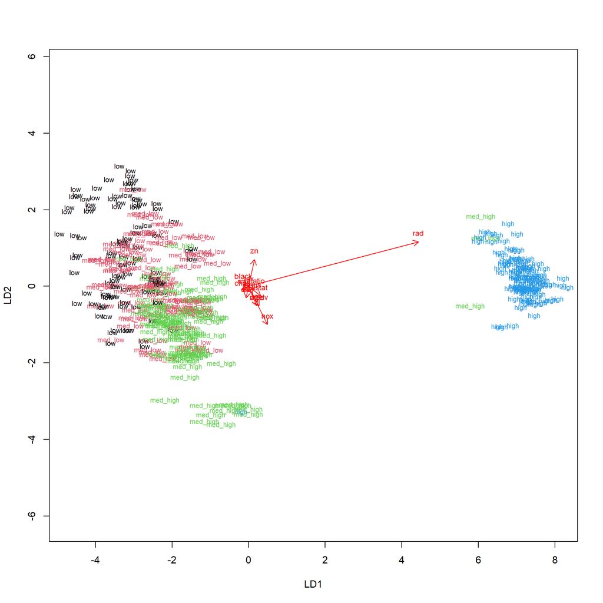

```r
# the function for lda biplot arrows
lda.arrows <- function(x, myscale = 1, arrow_heads = 0.1, color = "red", tex = 0.75, choices = c(1,2)){
  heads <- coef(x)
  graphics::arrows(x0 = 0, y0 = 0,
                   x1 = myscale * heads[,choices[1]],
                   y1 = myscale * heads[,choices[2]], col=color, length = arrow_heads)
  text(myscale * heads[,choices], labels = row.names(heads),
       cex = tex, col=color, pos=3)
}

# target classes as numeric
classes <- as.numeric(train$crime)

# plot the lda results
plot(lda.fit, dimen = 2, col=classes, pch = classes)
lda.arrows(lda.fit, myscale = 1.2)
```

- The biplot:
  - The cosine of the angle between a vector and an axis indicates the importance of the contribution of the corresponding variable to the principal component
  - variables are shown as arrows from the origin and observations are shown as points. The configuration of arrows reflects the relations of the variables. The cosine of the angle between the arrows reflects the correlation between the variables they represent. The most influential linear separators for the clusters are zn, rad & nox.

```r
# predict classes with test data
lda.pred <- predict(lda.fit, newdata = test)

# cross tabulate the results
table(correct = correct_classes, predicted = lda.pred$class)
```

```
##           predicted
## correct    low med_low med_high high
##   low       16       7        0    0
##   med_low    3      20        9    0
##   med_high   0       7       19    3
##   high       0       0        0   18
```

##### Clustering

Cluster analysis is a generic term for a wide range of numerical methods with the common goal of uncovering or discovering groups or clusters of observations that are homogeneous and separated from other groups. Clusters are identified by the assessment of the relative distances between points. Clustering means that some points (or observations) of the data are in some sense closer to each other than some other points.

Classifcation starts with calculating interindividual distance matrix or similarity matrix. There are many ways to calculate distances or similarities between pairs of individuals, here we use Euclidean distance. After calculating distances, we proceed to run the k-means algorithm.

K-means clustering is a unsupervised method, that assigns observations to groups or clusters based on similarity of the objects

```r
data("Boston") #load the data again

boston_scaled_2 <- scale(Boston) # scaling variables
boston_scaled_2<-as.data.frame(boston_scaled_2) # change the object to data frame

dist_eu <- dist(boston_scaled_2) # euclidean distance matrix

summary(dist_eu) # look at the summary of the distances
```

```
##    Min. 1st Qu.  Median    Mean 3rd Qu.    Max.
##  0.1343  3.4625  4.8241  4.9111  6.1863 14.3970
```

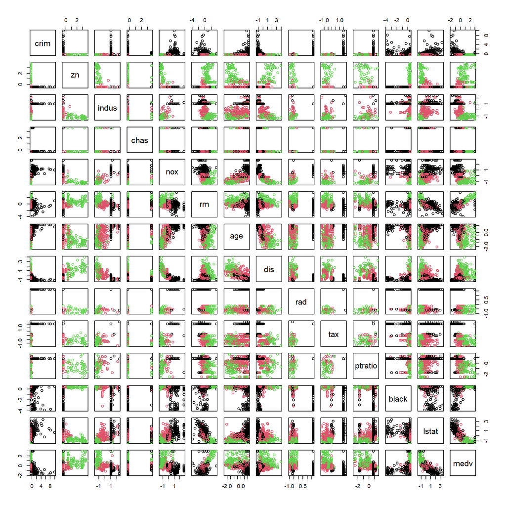

```r
# k-means clustering
km <- kmeans(boston_scaled_2, centers = 3) #centers = number of clusters

# plot the Boston dataset with clusters
pairs(boston_scaled_2, col = km$cluster)
```

Summary table of eucledian distances show the min, 1st quartile, median, mean, 3rd quartile and maximum of the distances between two points.

Let’s determine the optimal number of clusters

When plotting the number of clusters and the total WCSS, the optimal number of clusters is when the total WCSS drops radically

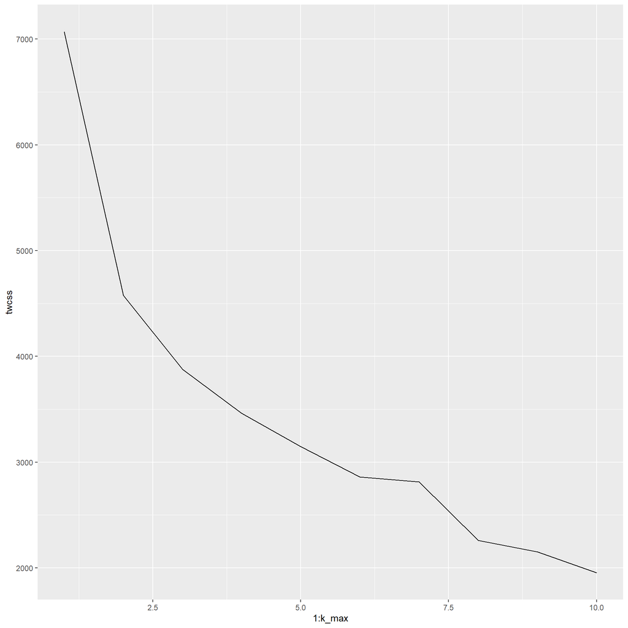

```r
#K-means might produce different results every time, because it randomly assigns the initial cluster centers. The function `set.seed()` can be used to deal with that.
set.seed(123)

# determine the number of clusters
k_max <- 10

# calculate the total within sum of squares
twcss <- sapply(1:k_max, function(k){kmeans(boston_scaled_2, k)$tot.withinss})

# visualize the results
qplot(x = 1:k_max, y = twcss, geom = 'line')
```

```r
km <- kmeans(boston_scaled_2, centers = 6) # k-means clustering

print(km)
```

```
## K-means clustering with 6 clusters of sizes 49, 47, 34, 78, 124, 174
##
## Cluster means:
##         crim         zn      indus       chas        nox         rm         age
## 1 -0.3774003 -0.1398479 -0.8703728 -0.2723291 -0.2390554  1.5399833  0.07933756
## 2 -0.2834643 -0.4872402  1.5965043 -0.2723291  1.0453673 -0.6245590  0.94375129
## 3 -0.1985497 -0.2602436  0.2799956  3.6647712  0.3830784  0.2756681  0.37213224
## 4 -0.4126954  1.9952361 -1.1032525 -0.2218534 -1.1552982  0.6080657 -1.40363754
## 5  1.1156495 -0.4872402  1.0149946 -0.2723291  0.9916473 -0.4276828  0.75159525
## 6 -0.3884148 -0.3253420 -0.4696145 -0.2723291 -0.4787024 -0.2866326 -0.25638178
##          dis          rad         tax    ptratio       black      lstat
## 1 -0.2868574 -0.520140581 -0.82627237 -1.0314738  0.35523433 -0.9636997
## 2 -0.8963217 -0.622669809  0.03772813 -0.2084479 -0.08717824  0.7185475
## 3 -0.4033382  0.001081444 -0.09756330 -0.3924585  0.17154271 -0.1643525
## 4  1.5772490 -0.627024335 -0.57588304 -0.7161406  0.35335146 -0.9028481
```

[output cut: 72 more lines]

- The k-means printed output displays:
  - sizes of the clusters
  - the cluster means or centers: a matrix, which rows are cluster number (1 to 6) and columns are variables
  - the clustering vector: A vector of integers (from 1:k) indicating the cluster to which each point is allocated

Let’s visualize the clusters with the pairs() function:

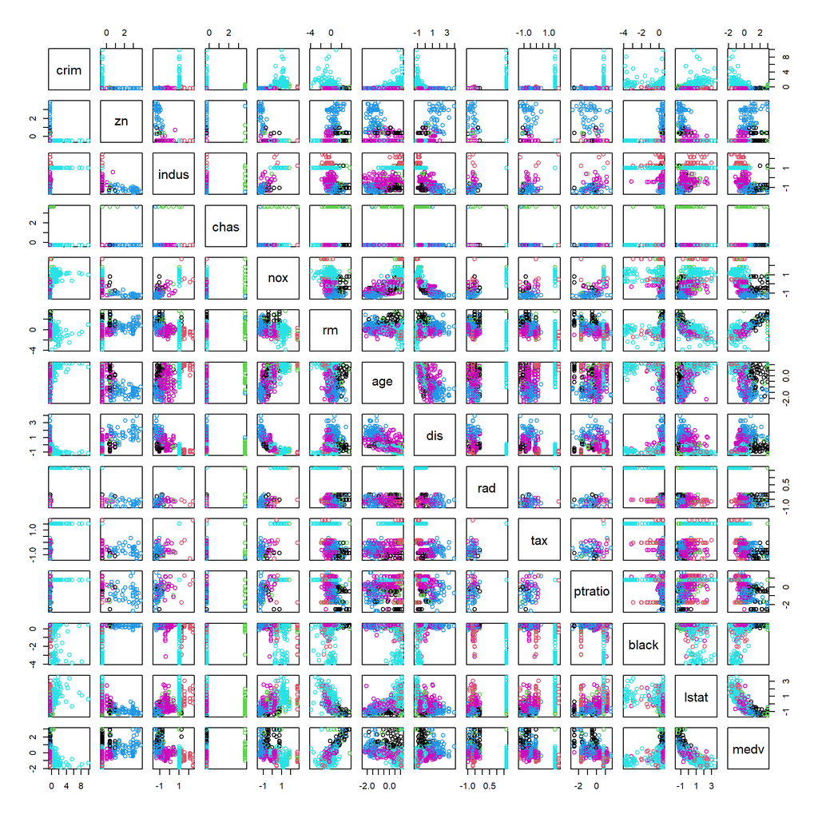

```r
pairs(boston_scaled_2, col = km$cluster)
```

- Here are some observations of the clustering visualization:
  - better accessibility to radial highways and property-tax rate increase seem to cluster together with high crime rate
  - lower median value of owner-occupied homes are classified to the same clusters with increasing crime rates
  - Variables industry and nitrogen form at least 3 clear clusters together.
  - Low status of the population is clustered with reduced median value of owner-occupied homes.

##### Bonus task:

```r
data("Boston")
boston_scaled_bonus <- scale(Boston) # scaling
boston_scaled_bonus<-as.data.frame(boston_scaled_bonus) # change the object to data frame

#clusters: km$cluster

#LDA
set.seed(123)
lda.fit_bonus <- lda(km$cluster~., data = boston_scaled_bonus)

lda.fit_bonus # print the lda.fit object
```

```
## Call:
## lda(km$cluster ~ ., data = boston_scaled_bonus)
##
## Prior probabilities of groups:
##          1          2          3          4          5          6
## 0.09683794 0.09288538 0.06719368 0.15415020 0.24505929 0.34387352
##
## Group means:
##         crim         zn      indus       chas        nox         rm         age
## 1 -0.3774003 -0.1398479 -0.8703728 -0.2723291 -0.2390554  1.5399833  0.07933756
## 2 -0.2834643 -0.4872402  1.5965043 -0.2723291  1.0453673 -0.6245590  0.94375129
## 3 -0.1985497 -0.2602436  0.2799956  3.6647712  0.3830784  0.2756681  0.37213224
## 4 -0.4126954  1.9952361 -1.1032525 -0.2218534 -1.1552982  0.6080657 -1.40363754
## 5  1.1156495 -0.4872402  1.0149946 -0.2723291  0.9916473 -0.4276828  0.75159525
## 6 -0.3884148 -0.3253420 -0.4696145 -0.2723291 -0.4787024 -0.2866326 -0.25638178
##          dis          rad         tax    ptratio       black      lstat
## 1 -0.2868574 -0.520140581 -0.82627237 -1.0314738  0.35523433 -0.9636997
## 2 -0.8963217 -0.622669809  0.03772813 -0.2084479 -0.08717824  0.7185475
## 3 -0.4033382  0.001081444 -0.09756330 -0.3924585  0.17154271 -0.1643525
## 4  1.5772490 -0.627024335 -0.57588304 -0.7161406  0.35335146 -0.9028481
## 5 -0.8170870  1.659602895  1.52941294  0.8057784 -0.81154619  0.9129958
## 6  0.2769540 -0.587168164 -0.59021294  0.1702603  0.30993538 -0.1365045
##         medv
## 1  1.6147330
## 2 -0.5152915
## 3  0.5733409
## 4  0.6621944
## 5 -0.7713403
## 6 -0.1747229
##
## Coefficients of linear discriminants:
##                   LD1         LD2          LD3         LD4         LD5
## crim    -0.0305347753 -0.08591377 -0.108258758  0.01370669  0.12793637
## zn      -0.2349745638 -0.08924451 -0.895982678 -1.47547778  0.34969495
## indus    0.1256678211 -0.64511317  1.388877801 -1.77654417  0.39972164
## chas     5.8325152872  0.24741612 -0.311207345 -0.07443844 -0.27828298
## nox     -0.0025874888  0.27316108  0.279998181 -0.33251185  0.43887081
## rm      -0.0806099076 -0.01151686 -0.148388969  0.12537565  0.56954956
## age      0.0721570288 -0.01868907  0.362844031  0.22642315  0.24959116
## dis      0.0698432704  0.27583463 -0.218044854 -0.54697937 -0.14293536
## rad      0.2608126124 -3.31540916 -1.507829403  1.14007512  0.04287448
## tax     -0.0049952119  0.23295413 -0.381672532 -0.48815038 -0.21073890
## ptratio -0.0007726087  0.08817263  0.041915486 -0.04862072 -0.32527265
## black    0.0078197790  0.09331354 -0.003179723  0.02328372 -0.03306096
## lstat   -0.1245078745 -0.13037037 -0.008198020 -0.03449407  0.25315537
## medv    -0.1868981610  0.34078428  0.026517982  0.20032076  0.88234880
##
## Proportion of trace:
##    LD1    LD2    LD3    LD4    LD5
## 0.6255 0.2484 0.0727 0.0387 0.0147
```

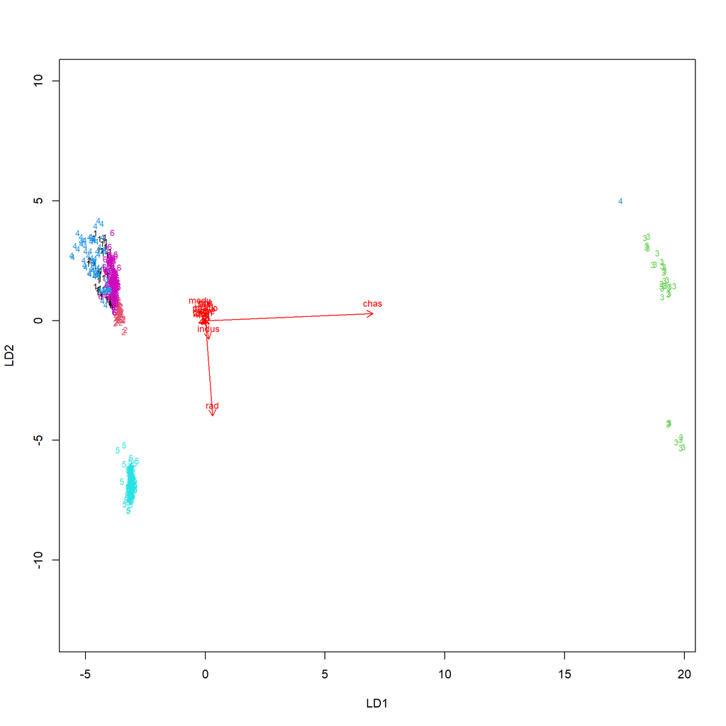

```r
# the function for lda biplot arrows
lda.arrows <- function(x, myscale = 1, arrow_heads = 0.1, color = "red", tex = 0.75, choices = c(1,2)){
  heads <- coef(x)
  graphics::arrows(x0 = 0, y0 = 0,
                   x1 = myscale * heads[,choices[1]],
                   y1 = myscale * heads[,choices[2]], col=color, length = arrow_heads)
  text(myscale * heads[,choices], labels = row.names(heads),
       cex = tex, col=color, pos=3)
}

# target classes as numeric
classes_bonus <- as.numeric(km$cluster)

# plot the lda results
plot(lda.fit_bonus, dimen = 2, col=classes_bonus, pch = classes_bonus)
lda.arrows(lda.fit_bonus, myscale = 1.2)
```

The most influential linear separators for the clusters are chas, rad & indus.

##### Super-Bonus:

```r
model_predictors <- dplyr::select(train, -crime)

# check the dimensions
dim(model_predictors)
```

```
## [1] 404  13
```

```r
dim(lda.fit$scaling)
```

```
## [1] 13  3
```

```r
# matrix multiplication
matrix_product <- as.matrix(model_predictors) %*% lda.fit$scaling
matrix_product <- as.data.frame(matrix_product)
```